# week 5 practical

2026-11-05

## 0. Analysis plan

Aim: compare hotels and Airbnb listings across London boroughs.

1. Load the data: London boroughs (shp), OSM points of interest (shp), Airbnb listings (csv), UK outline and world cities (for the location map).
2. Set every layer to British National Grid (EPSG:27700), so they line up.
3. Filter: keep only hotels from OSM, and only whole-home Airbnbs available all year (comparable to hotels).
4. Spatial join: count how many hotels and Airbnbs fall in each borough.
5. Normalise the counts (per km²), because larger boroughs naturally contain more points.
6. Map: two maps side by side (A hotels, B Airbnb), a UK location map, legend, north arrow, scale bar and data source.

## 1. Load data

```r
# packages: tidyverse (data cleaning), sf (spatial data),
# janitor (tidy column names), tmap (maps)
library(tidyverse)
library(sf)
library(janitor)
library(tmap)

# London boroughs (already in British National Grid)
london_boroughs <- st_read("prac5_data/statistical-gis-boundaries-london/ESRI/London_Borough_Excluding_MHW.shp") %>%
  clean_names() %>%
  st_transform(27700)
# OSM points of interest (shops, hotels, cafes...)
osm <- st_read("prac5_data/greater-london-latest-free.shp/gis_osm_pois_free_1.shp") %>%
  clean_names() %>%
  st_transform(27700)
# Airbnb listings (a normal table with longitude/latitude columns)
airbnb <- read_csv("prac5_data/listings.csv") %>%
  clean_names()
```

## 2. Filter

```r
# keep only hotels from OSM
hotels <- osm %>%
  filter(fclass == "hotel")

# keep whole homes available all year, then turn the table into points
airbnb_points <- airbnb %>%
  filter(room_type == "Entire home/apt" & availability_365 == 365) %>%
  st_as_sf(coords = c("longitude", "latitude"), crs = 4326) %>%
  st_transform(27700)

# check how many points are left after filtering
nrow(hotels)
```

```
## [1] 367
```

```r
nrow(airbnb_points)
```

```
## [1] 2363
```

## 3. Count per borough

```r
# count the points inside each borough (st_intersects + lengths),
# then divide by area (m² / 1,000,000 = km²) to get density,
# because bigger boroughs naturally contain more points
london_boroughs <- london_boroughs %>%
  mutate(hotel_count  = lengths(st_intersects(., hotels)),
         airbnb_count = lengths(st_intersects(., airbnb_points)),
         area_km2     = as.numeric(st_area(.)) / 1000000,
         hotel_density  = hotel_count / area_km2,
         airbnb_density = airbnb_count / area_km2)

# show the boroughs with the highest hotel density (table only, no geometry)
london_boroughs %>%
  st_drop_geometry() %>%
  select(name, hotel_count, airbnb_count, hotel_density, airbnb_density) %>%
  arrange(desc(hotel_density)) %>%
  head()
```

```
##             name hotel_count airbnb_count hotel_density airbnb_density
## 1 City of London          19           37     6.5428673      12.741373
## 2    Westminster          81          505     3.7697253      23.502608
## 3         Camden          76          115     3.4879512       5.277821
## 4      Islington          14           60     0.9423388       4.038595
## 5  Tower Hamlets          16          109     0.8089823       5.511192
## 6        Hackney          15           54     0.7874418       2.834790
```

## 4. Maps

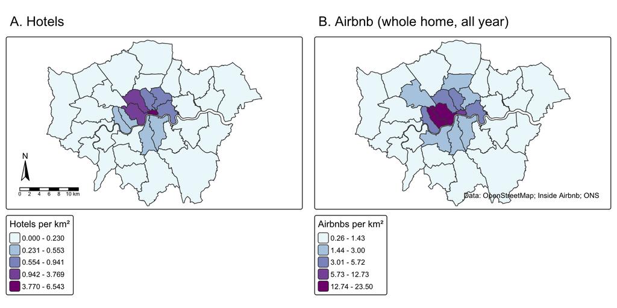

```r
tmap_mode("plot")   # static map (not interactive)

# map A: hotel density, jenks breaks (natural groups), 5 classes
map_hotels <- tm_shape(london_boroughs) +
  tm_polygons(fill = "hotel_density",
              fill.scale = tm_scale_intervals(style = "jenks", n = 5, values = "brewer.bu_pu"),
              fill.legend = tm_legend(title = "Hotels per km²")) +
  tm_title("A. Hotels") +
  tm_compass(position = c("left", "bottom")) +
  tm_scalebar(position = c("left", "bottom"))

# map B: Airbnb density, same style so the two maps can be compared
map_airbnb <- tm_shape(london_boroughs) +
  tm_polygons(fill = "airbnb_density",
              fill.scale = tm_scale_intervals(style = "jenks", n = 5, values = "brewer.bu_pu"),
              fill.legend = tm_legend(title = "Airbnbs per km²")) +
  tm_title("B. Airbnb (whole home, all year)") +
  tm_credits("Data: OpenStreetMap; Inside Airbnb; ONS", position = c("right", "bottom"))

# put the two maps side by side
tmap_arrange(map_hotels, map_airbnb, ncol = 2)
```

## 5. Location map

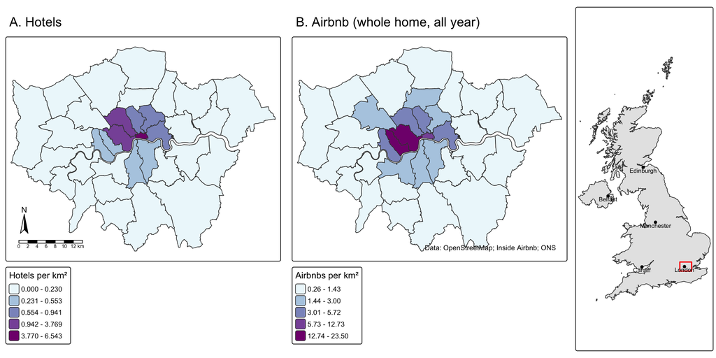

```r
# UK outline (simplified so it draws faster)
uk_outline <- st_read("prac5_data/gadm41_GBR_shp/gadm41_GBR_0.shp") %>%
  st_transform(27700) %>%
  st_simplify(dTolerance = 1000)
# a few UK cities for reference
uk_cities <- st_read("prac5_data/World_Cities.geojson") %>%
  clean_names() %>%
  filter(cntry_name == "United Kingdom",
         city_name %in% c("London", "Edinburgh", "Cardiff", "Belfast", "Manchester")) %>%
  st_transform(27700)
# a box around London, to show where the study area is
london_box <- st_as_sfc(st_bbox(london_boroughs))

# location map: UK in grey, red box = London, dots = cities
map_uk <- tm_shape(uk_outline) +
  tm_polygons(fill = "grey90") +
  tm_shape(london_box) +
  tm_borders(col = "red", lwd = 2) +
  tm_shape(uk_cities) +
  tm_dots(size = 0.3) +
  tm_text("city_name", size = 0.6, ymod = -0.6)

# combine all three maps (London maps wider than the UK map)
final_map <- tmap_arrange(map_hotels, map_airbnb, map_uk,
                          ncol = 3, widths = c(0.4, 0.4, 0.2))
final_map
```

```r
# save the final map as a 300 dpi image
# (png opens the file, print draws the map, dev.off closes and saves it)
png("week5_map.png", width = 12, height = 6, units = "in", res = 300)
print(final_map)
dev.off()
```

## 6. Interpretation

Both maps show the same core pattern: hotels and whole-home Airbnb listings are concentrated in central London (Westminster, Camden, City of London) and become much less dense towards the outer boroughs. However, Airbnb is far more common: there are about 2,363 full-year whole-home listings compared with 367 hotels, and the highest Airbnb density (about 23 per km²) is almost four times the highest hotel density (about 6.5 per km²). Airbnb also spreads further east, into boroughs such as Tower Hamlets and Hackney, where there are few hotels. This suggests short-term lets reach residential areas that the hotel industry does not.

Limitations: boroughs are large and arbitrary units, so the pattern could change with smaller areas (the modifiable areal unit problem). OpenStreetMap hotel data is volunteered and may be incomplete, and Inside Airbnb is a snapshot that does not show whether a listing is actually booked.